# (Flight Delay and Cancelation Analysis)

## by (Ahmed Hashem)

## Investigation Overview

> We need to elaborate the reasons for flight delays and the main impacted trips

## Dataset Overview

> This dataset reports flights in the United States, including carriers, arrival and departure delays, and reasons for delays, from 2003 to 2008.

## (Flight Timing)

> Rarely found any trips from midnight to 5 AM

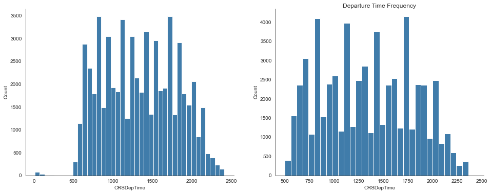

```python
fig, ax = plt.subplots(figsize=(16, 6), ncols=2)

sb.histplot(df.CRSDepTime, kde=False, color=base_color, binwidth=60, ax=ax[0])
sb.despine()
plt.title('Departure Time Frequency',pad=1.5)
sb.histplot(df.CRSDepTime, kde=False, color=base_color, binwidth=60, ax=ax[1], binrange=[500, 2400])
sb.despine()
```

## (Cancelation Reasons)

> Carrier was the most frequent reason for cancellation

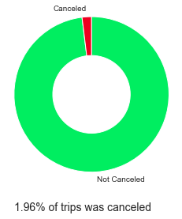

```python
canceled_df = df.Cancelled.value_counts()

plt.pie(canceled_df,
       labels = ['Not Canceled', 'Canceled'],
       startangle=90,
       counterclock=False,
       wedgeprops={'width': 0.5},
       colors=['#00ee60', '#ee0020'])
plt.axis('square')
plt.text(-1, -1.5, f'{canceled_df[1]/canceled_df.sum():.2%} of trips was canceled', fontdict={'fontsize': 14})
plt.show()
```

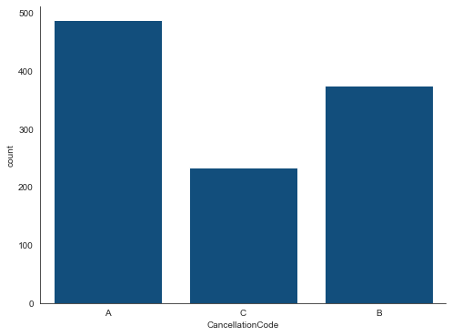

```python
fig, ax = plt.subplots(figsize=(8, 6))

sb.countplot(data=df, x='CancellationCode', color=base_color, ax=ax)
sb.despine()
```

## Top 10 Trips (Origin-Destination) with delaysover years

```python
#Using Feture Engineering to add trip coloumn to measure the hall trip Origin-Destination impact:
df["trip"]=df["Origin"]+"-"+df["Dest"]

#Adding Total Delay for all Delay Categories
df['TotalDelay']=df[['CarrierDelay', 'WeatherDelay', 'NASDelay', 'SecurityDelay']].sum(axis=1, min_count=1)
```

```python
trip_groups_years=df[['Year','trip','CarrierDelay','WeatherDelay','NASDelay','SecurityDelay','TotalDelay']]\
                                                             .groupby(['Year','trip']).median().reset_index()
trip_groups_years
```

|  | Year | trip | CarrierDelay | WeatherDelay | NASDelay | SecurityDelay | TotalDelay |
| --- | --- | --- | --- | --- | --- | --- | --- |
| 0 | 2003 | ABE-ATL | NaN | NaN | NaN | NaN | NaN |
| 1 | 2003 | ABE-CLE | 0.0 | 0.0 | 0.0 | 0.0 | 0.0 |
| 2 | 2003 | ABE-ORD | 0.0 | 0.0 | 0.0 | 0.0 | 0.0 |
| 3 | 2003 | ABI-DFW | 0.0 | 0.0 | 0.0 | 0.0 | 0.0 |
| 4 | 2003 | ABQ-AMA | 0.0 | 0.0 | 0.0 | 0.0 | 0.0 |
| ... | ... | ... | ... | ... | ... | ... | ... |
| 18566 | 2008 | XNA-ORD | NaN | NaN | NaN | NaN | NaN |
| 18567 | 2008 | YKM-SLC | 23.0 | 0.0 | 0.0 | 0.0 | 23.0 |
| 18568 | 2008 | YUM-IPL | NaN | NaN | NaN | NaN | NaN |
| 18569 | 2008 | YUM-LAX | NaN | NaN | NaN | NaN | NaN |
| 18570 | 2008 | YUM-PHX | 31.0 | 0.0 | 0.0 | 0.0 | 31.0 |

18571 rows × 7 columns

## Bivariate Exploration

> To start off with, I want to look at the pairwise correlations present between features in the data.

```python
#Carrier Delays Top 10 Trips
carrier_delays_10=trip_groups.sort_values('CarrierDelay',ascending=False)[:10][['trip', 'CarrierDelay']]
carrier_delays_10
```

|  | trip | CarrierDelay |
| --- | --- | --- |
| 4065 | SAT-MEM | 1057.0 |
| 4005 | SAN-CLE | 679.0 |
| 4721 | TYS-DFW | 659.0 |
| 3956 | ROC-DTW | 593.0 |
| 484 | BOI-MSP | 514.0 |
| 3193 | MSY-DFW | 380.0 |
| 687 | CAK-ATL | 357.0 |
| 4081 | SAV-ATL | 356.0 |
| 894 | CMH-LGA | 340.0 |
| 3746 | PIH-SLC | 338.5 |

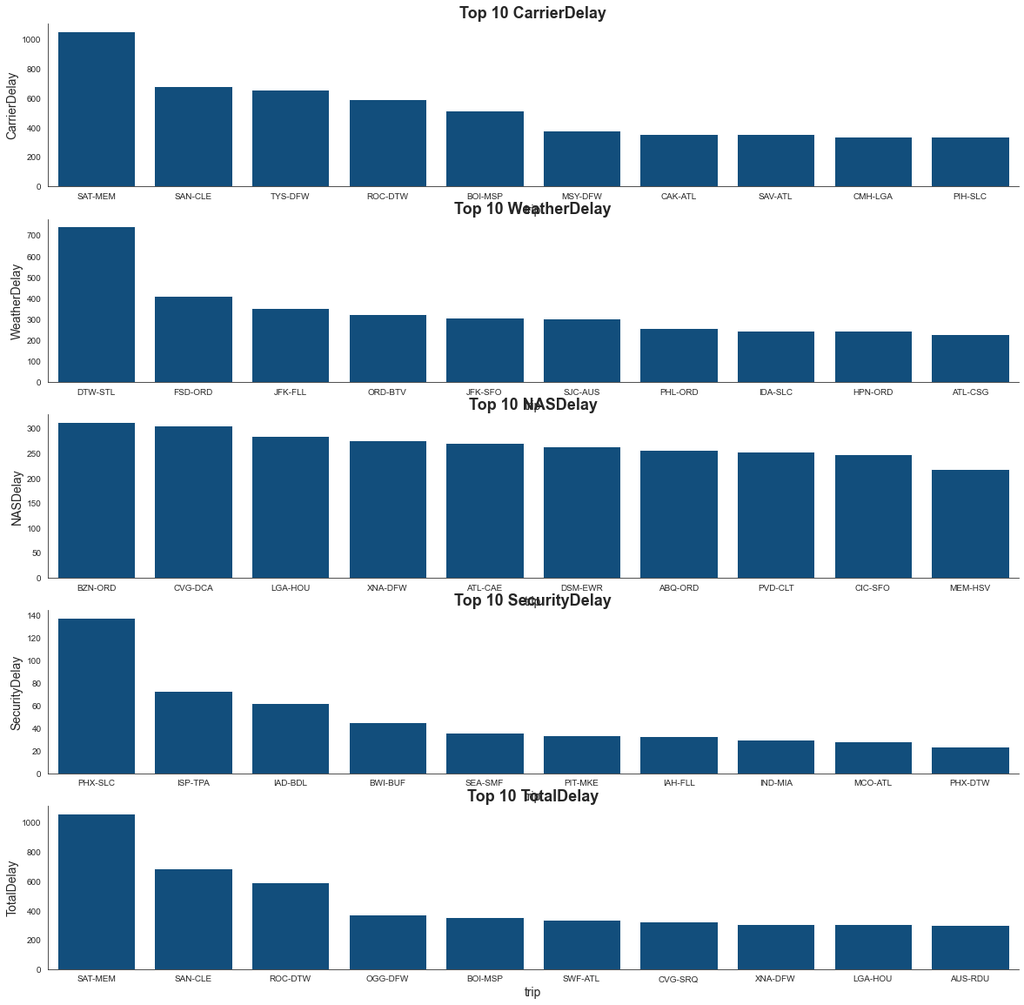

```python
cols = ['CarrierDelay', 'WeatherDelay', 'NASDelay', 'SecurityDelay','TotalDelay']
fig, ax = plt.subplots(nrows=5, figsize = [20,20])

for i, col in enumerate(cols):
    df_loop=trip_groups.sort_values(col,ascending=False)[:10]
    sb.barplot(data=df_loop,x='trip',y=col,color=base_color, ax=ax[i])
    sb.despine()
    ax[i].set_title('Top 10 ' + col ,fontdict=title_font_dict)
    ax[i].set_xlabel(ax[i].get_xlabel(),fontdict=labels_font_dict)
    ax[i].set_ylabel(ax[i].get_ylabel(),fontdict=labels_font_dict)
```

# Trips median Delayed

> Identify Top 10 trips with delays using Median to avoid extremes in data points

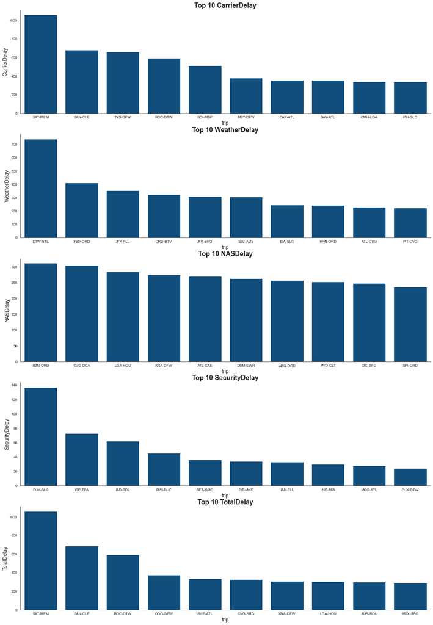

```python
cols = ['CarrierDelay', 'WeatherDelay', 'NASDelay', 'SecurityDelay','TotalDelay']
fig, ax = plt.subplots(nrows=5, figsize = [20,30])

for i, col in enumerate(cols):
    df_loop=trip_groups_median.sort_values(col,ascending=False)[:10]
    sb.barplot(data=df_loop,x='trip',y=col,color=base_color, ax=ax[i])
    sb.despine()
    ax[i].set_title('Top 10 ' + col ,fontdict=title_font_dict)
    ax[i].set_xlabel(ax[i].get_xlabel(),fontdict=labels_font_dict)
    ax[i].set_ylabel(ax[i].get_ylabel(),fontdict=labels_font_dict)
```

[output not shown]

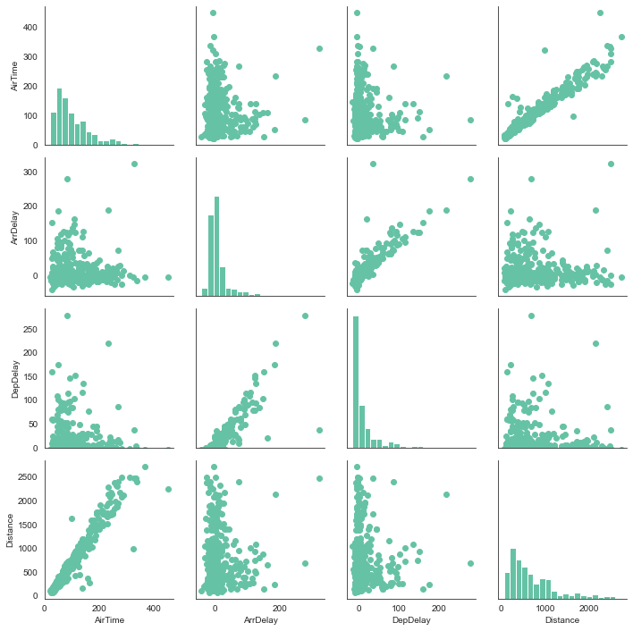

```python
# plot matrix: sample 500 datapoint so that plots are clearer and
# they render faster
samples = np.random.choice(df.shape[0], 500, replace = False)
df_samp = df.iloc[samples,:]

g = sb.PairGrid(data = df_samp, vars = numeric_vars)
g = g.map_diag(plt.hist, bins = 20);
g.map_offdiag(plt.scatter)
plt.ylim(bottom=0)
plt.show
```

### How did the feature(s) of interest vary with other features in the dataset?

> Air Time have outlier with distance taken need more detailed invistigation.

### Interesting relationships between the other features (not the main feature(s) of interest)?

> Departure Delay having outliers with Arrival delay correlations

## Multivariate Exploration

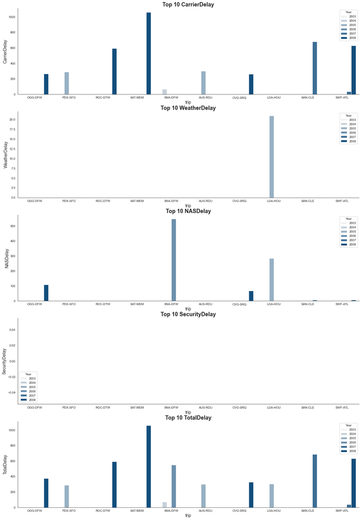

```python
# Trying to explore the top 10 trips per delay reason,and allocate them with diffrent years,(Origin-Destination)
#to check if their are specific trips having always delays over years
cols = ['CarrierDelay', 'WeatherDelay', 'NASDelay', 'SecurityDelay','TotalDelay']
fig, ax = plt.subplots(nrows=5, figsize = [20,30])

df_loop=trip_groups_years.query('trip in @most_delayed')
for i, col in enumerate(cols):
    sb.barplot(data=df_loop,x='trip',y=col, hue='Year', color=base_color, ax=ax[i])
    sb.despine()
    ax[i].set_title('Top 10 ' + col ,fontdict=title_font_dict)
    ax[i].set_xlabel(ax[i].get_xlabel(),fontdict=labels_font_dict)
    ax[i].set_ylabel(ax[i].get_ylabel(),fontdict=labels_font_dict)
```

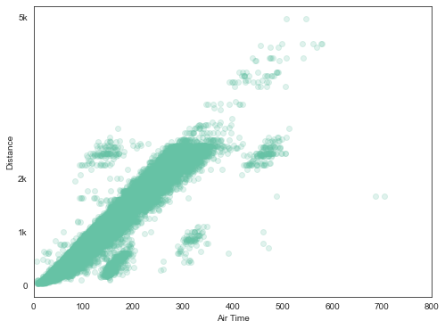

```python
plt.figure(figsize = [8, 6])
plt.scatter(data = df, x = 'AirTime', y = 'Distance', alpha = 1/5)
plt.xlim([0, 800])
plt.xlabel('Air Time')
plt.yscale('Linear')
plt.yticks([0, 1e3, 2e3, 5e3], [0, '1k', '2k', '5k'])
plt.ylabel('Distance')
plt.show()
```

### Talk about some of the relationships you observed in this part of the investigation. Were there features that strengthened each other in terms of looking at your feature(s) of interest?

> The Top 10 trips having delays are not the same trips over the years Most delayed reason over the years is the carrier delay.

### Were there any interesting or surprising interactions between features?

> Although Airtime expected to be linear positive correlation with distance ,their are outliers that may need more invistagation.